# Modelos Lineares Generalizados - Regressão Robusta

Jose Storopoli

Lembrando da curva normal gaussiana que possui um formato de sino. Ela não é muito alongada nas “pontas”. Ou seja, as observações não fogem muito da média. Quando usamos essa distribuição como verossimilhança na inferência modelos Bayesianos, forçamos a que todas as estimativas sejam condicionadas à uma distribuição normal da variável dependente. Se nos dados houverem muitas observações com valores discrepantes (bem diferentes da média - *outliers*), isso faz com que as estimativas dos coeficientes das variáveis independentes fiquem instáveis. Isso ocorre porquê a distribuição normal não consegue contemplar observações muito divergentes da média sem mudar a média de local.

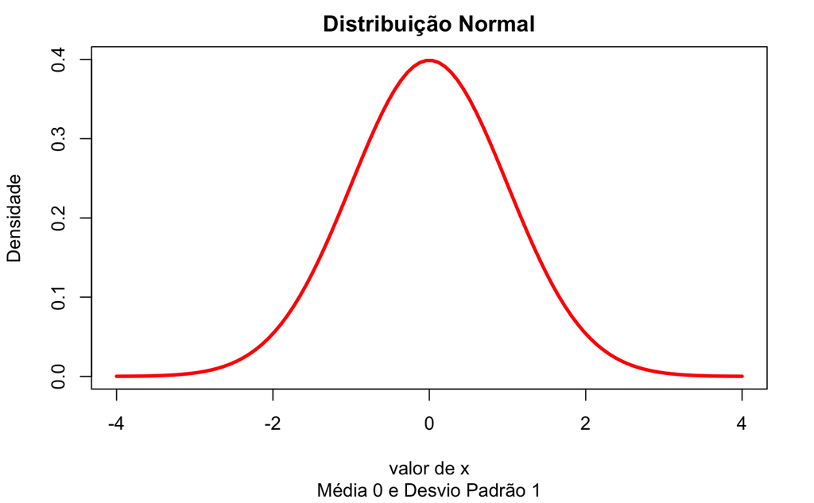

```r
x <- seq(-4, 4, length = 100)
plot(x, dnorm(x),
     type = "l",
     col = "red",
     lwd = 3,
     xlab="valor de x",
     ylab="Densidade",
     main="Distribuição Normal",
     sub = "Média 0 e Desvio Padrão 1",
     xlim = c(-4, 4),
     ylim = c(0, 0.4))
```

Então precisamos de uma distribuição mais “maleável” como verossimilhança. Precisamos de uma distribuição que seja mais robusta à observações discrepantes (*outliers*). Precisamos de uma distribuição similar à Normal mas que possua caudas mais longas para justamente contemplar observações muito longe da média sem ter que mudar a média de local. Para isso temos a distribuição t de Student. Lembrando o formato dela:

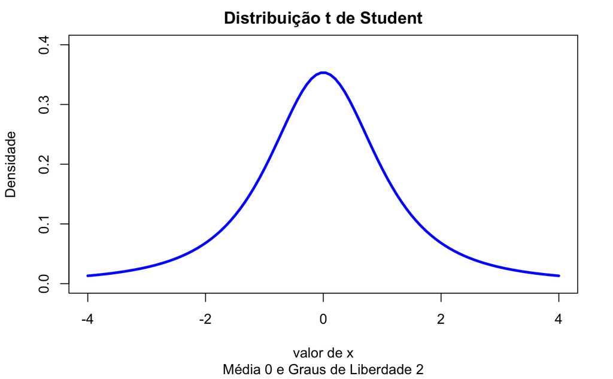

```r
x <- seq(-4, 4, length = 100)
plot(x, dt(x, 2),
     type = "l",
     col = "blue",
     lwd = 3,
     xlab="valor de x",
     ylab="Densidade",
     main="Distribuição t de Student",
     sub = "Média 0 e Graus de Liberdade 2",
     xlim = c(-4, 4),
     ylim = c(0, 0.4))
```

## Comparativo Normal vs Student

Reparem nas caudas:

```r
plot(NA, xlab="valor de x",
  ylab = "Densidade",
  main = "Comparativo de Distribuições",
  sub = "Normal vs t de Student",
  xlim = c(-4, 4),
  ylim = c(0, 0.4))
lines(x, dnorm(x), lwd = 2, col = "red")
```

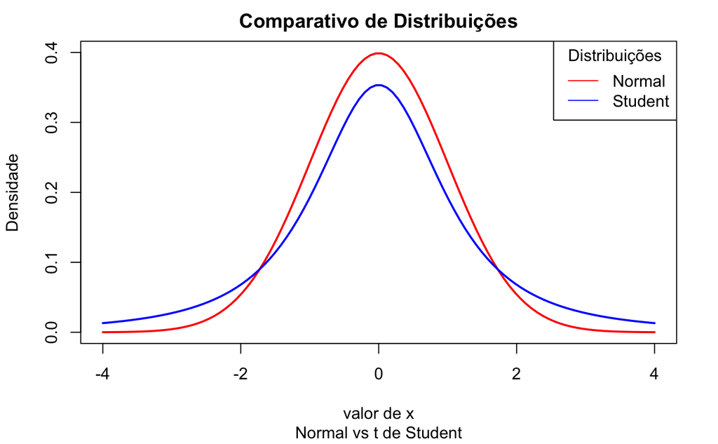

```r
lines(x, dt(x, df = 2), lwd = 2, col = "blue")
legend("topright", legend=c("Normal", "Student"),
       col=c("red", "blue"), title="Distribuições", lty=1)
```

## Modelos Lineares Robustos com o pacote `brms`

O `rstanarm` não possui a possibilidade de usar distribuições t de Student como verossimilhança do modelo Bayesiano. Para usarmos distribuições t de Student, precisamos do pacote [`brms`](https://paul-buerkner.github.io/brms/). O `brms` usa a mesma síntaxe que o `rstanarm` e a única diferença é que o `brms` não possui os modelos pré-compilados então os modelos devem ser todos compilados antes de serem rodados. A diferença prática é que você irá esperar alguns instantes antes do R começar a simular MCMC e amostrar do modelo.

A função que usa-se para designar modelos lineares no `brms` é a `brm()`:

```r
brm(y ~ x1 + x2 + x3,
    data = df,
    family = student)
```

### Exemplo com os dados de Prestígio de Duncan (1961)

Para exemplicar regressão robusta vamos usar um *dataset* que tem muitas observações discrepantes (*outliers*) chamado `Duncan`. Ele possui 45 observações sobre ocupações nos EUA e 4 variáveis:

- `type`: Tipo de ocupação. Uma variável qualitativa:
  - `prof` - profissional ou de gestão
  - `wc` - white-collar (colarinho branco)
  - `bc` - blue-collar (colarinho azul)
- `income`: Porcentagem de pessoas da ocupação que ganham acima $ 3.500 por ano em 1950 (mais ou menos $36.000 em 2017);
- `education`: Porcentagem de pessoas da ocupação que possuem diploma de ensino médio em 1949 (que, sendo cínicos, podemos dizer que é de certa maneira equivalente com diploma de Doutorado em 2017); e
- `prestige`:Porcentagem de respondentes na pesquisa que classificam a sua ocupação como no mínimo “boa” em respeito à prestígio.

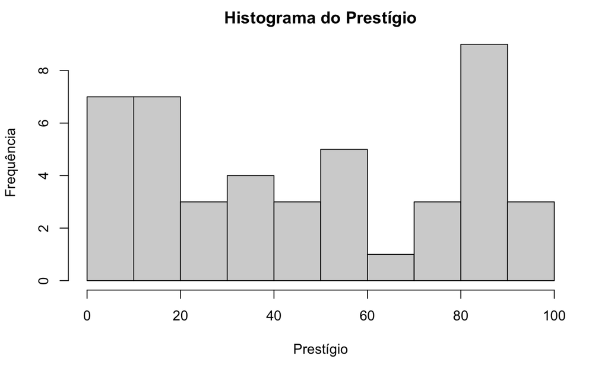

```r
duncan <- read.csv2("datasets/Duncan.csv", row.names = 1, stringsAsFactors = T)

hist(duncan$prestige,
     main = "Histograma do Prestígio",
     xlab = "Prestígio",
     ylab = "Frequência")
```

#### Primeiro modelo: Regressão Linear

Vamos estimar primeiramente uma regressão linear usando a distribuição Normal como verossimilhança:

```r
library(rstanarm)
model_1 <- stan_glm(
  prestige ~ income + education,
  data = duncan,
  family = gaussian
)
```

```
starting worker pid=10449 on localhost:11159 at 09:01:10.157
starting worker pid=10467 on localhost:11159 at 09:01:10.388
```